# Case Study for Seedstar

Rodrigo Taira

6 December 2018

## Introduction

- This is a presentation of a task given as an assignment for the Seedstar Data Scientist Internship Position.
- To implement this case, it was used R programming language as main tool for data analysis.
- Most part of the graphs were implemented using ggplot2 library.

## Problem Assignment and Questions

- A dataset was provided by this link: https://docs.google.com/spreadsheets/d/1YT0-PTttD-k1y8KHXwfHm5rkfOucIj-eGLvSiFOCchY/edit#gid=0
- In a brief view, it can be perceived that the data provided is about loans status from customers.
- It was asked to analyze this dataset and create a model to predict the ‘label’ index. That has just two possible values either ‘0’ and ‘1’.
- Some of the details that were very useful to get some insights were Education_Status, Gender, No_Children and Amount.
- How the Label Status is distributed considering Education Status, Reason, Number of Children and etc?

## Acquire Data

- First step was to retrieve the data from the link with the gsheet library.
- After a quick look, I got the summary of the data to check all the data types.
- It was organised the data types of each column and check which type suits better to the context for a better analysis of the data.

```r
library(gsheet)
dataset <- gsheet2tbl('https://docs.google.com/spreadsheets/d/1YT0-PTttD-k1y8KHXwfHm5rkfOucIj-eGLvSiFOCchY/edit#gid=0')
dataset$Education_Status <- as.factor(dataset$Education_Status)
dataset$Amount <- as.numeric(dataset$Amount)
dataset$Gender <- as.factor(dataset$Gender)
dataset$Reason <- as.factor(dataset$Reason)
dataset$label <- as.factor(dataset$label)
dataset$Reason <- as.factor(dataset$Reason)
dataset$referrals <- as.factor(dataset$referrals)
dataset$Name <- as.character(dataset$Name)
dataset$No_Children <- as.factor(dataset$No_Children)
dataset_no_na <- na.omit(dataset)
dataset_with_na <- dataset[!complete.cases(dataset),]

dataset[!complete.cases(dataset),]
```

```
## # A tibble: 710 x 12
##    User_ID label Education_Status Name  Gender   Age No_Children referrals
##      <int> <fct> <fct>            <chr> <fct>  <dbl> <fct>       <fct>
##  1       1 0     3                Jarr… male      22 1           0
##  2       3 1     3                Leen… female    26 0           0
##  3       5 0     3                Erwi… male      35 0           0
##  4       6 0     3                Jame… male      NA 0           0
##  5       8 0     3                Mont… male       2 3           1
##  6       9 1     3                Roch… female    27 0           2
##  7      10 1     2                Edra… female    14 1           0
##  8      13 0     3                Myle… male      20 0           0
##  9      14 0     3                Just… male      39 1           5
## 10      15 0     3                Ceci… female    14 0           0
## # ... with 700 more rows, and 4 more variables: loan_ident <chr>,
## #   Amount <dbl>, Campaign <chr>, Reason <fct>
```

- Plot to check how the ‘label’ is distributed among the Customers.

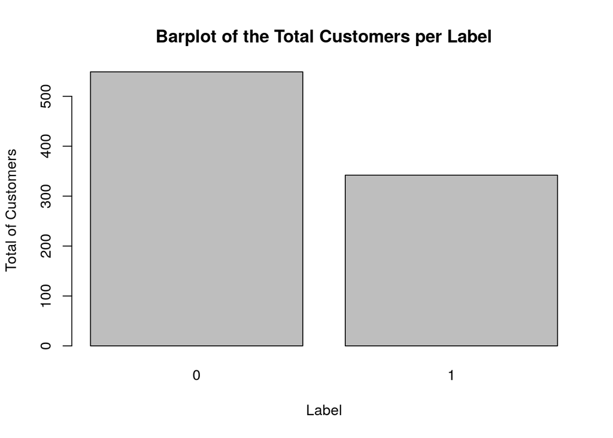

```r
barplot(table(dataset$label), xlab = "Label", ylab = "Total of Customers", main = "Barplot of the Total Customers per Label")
```

## Process of the data for analysis

- The probability of label be ‘1’ is higher for females with better education.

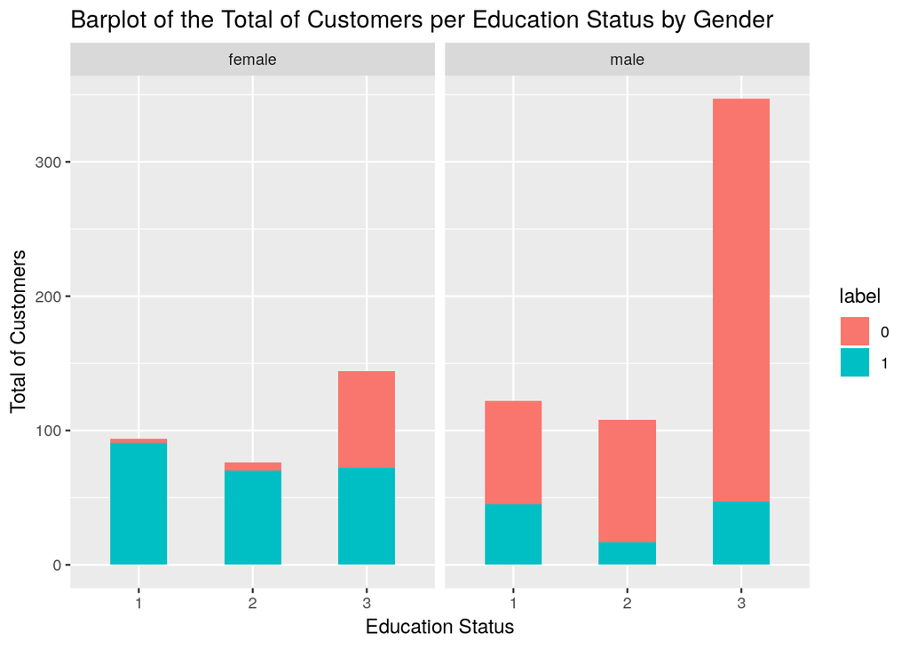

```r
library(ggplot2)
ggplot(dataset, aes(x = Education_Status, fill = factor(label))) + facet_wrap(~Gender) +  stat_count(width = 0.5) + xlab("Education Status") + ylab("Total of Customers") + labs(fill="label") + ggtitle('Barplot of the Total of Customers per Education Status by Gender')
```

- The probability of label be ‘1’ is higher for females with less or no Children.

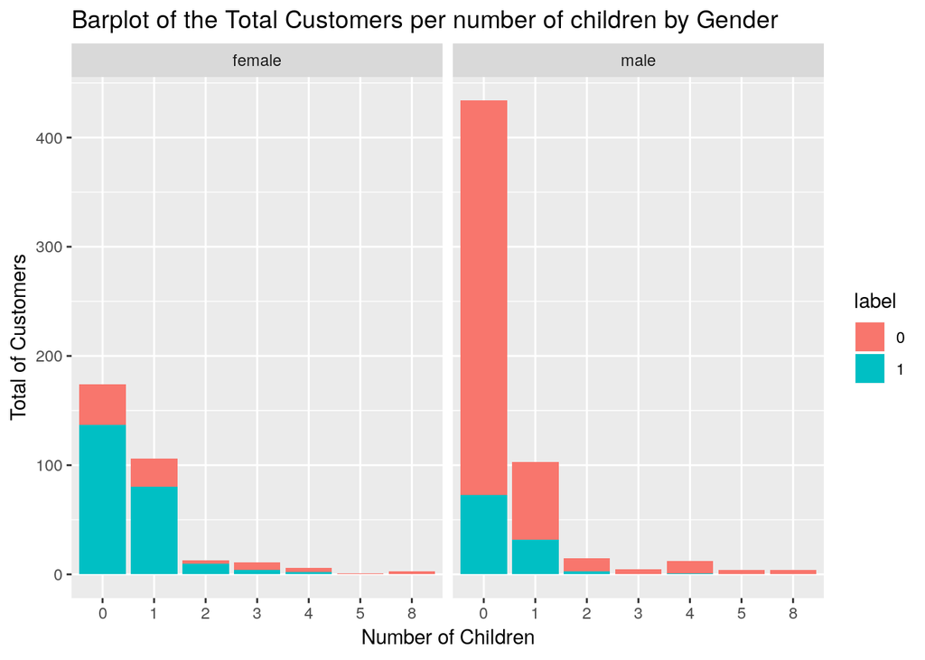

```r
ggplot(dataset, aes(x = No_Children, fill = label)) + geom_bar() + facet_wrap(~Gender) + xlab("Number of Children") + ylab("Total of Customers") + ggtitle('Barplot of the Total Customers per number of children by Gender')
```

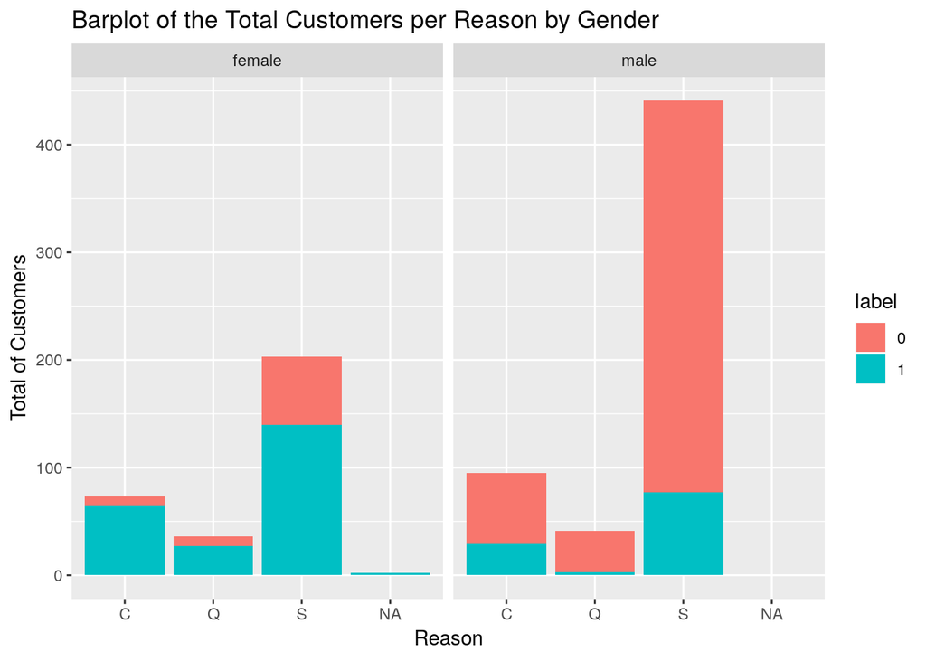

```r
ggplot(dataset, aes(x = Reason, fill = label)) + geom_bar() + facet_wrap(~Gender) + xlab("Reason") + ylab("Total of Customers") + ggtitle('Barplot of the Total Customers per Reason by Gender')
```

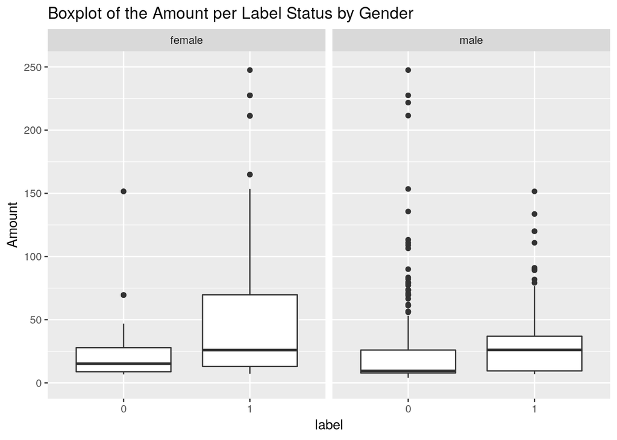

```r
ggplot(dataset, aes(x = label, y = Amount)) + geom_boxplot() + ggtitle("Boxplot of the Amount per Label Status by Gender") + facet_wrap(~Gender) + scale_y_continuous(limits = c(0,250))
```

##

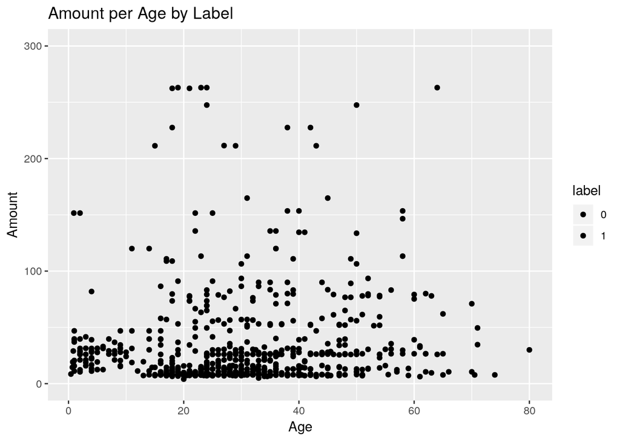

```r
library(ggplot2)
ggplot(aes(x = Age, y = Amount, fill = label), data = dataset ) +
  geom_point() + labs(fill="label") + ylim(c(0, 300)) + ggtitle("Amount per Age by Label")
```

## Prediction Model

```r
library(randomForest)
library(caTools)

str(dataset)
```

[output not shown]

```r
dim(dataset)
```

```
## [1] 891  12
```

```r
apply(dataset, 2, function(x) length(unique(x)))
```

```
##          User_ID            label Education_Status             Name
##              891                2                3              891
##           Gender              Age      No_Children        referrals
##                2               89                7                7
##       loan_ident           Amount         Campaign           Reason
##              681              248              148                4
```

```r
##set.seed(123)
ind <- sample.split( Y = dataset$label, SplitRatio = 0.8)
train_dataset <- dataset[ind,]
test_dataset <- dataset[!ind,]
train_dataset$Age <- na.roughfix(train_dataset$Age)
train_dataset$Name <- NULL
train_dataset$loan_ident <-NULL
train_dataset <- na.omit(train_dataset)
cleandata <- dataset[complete.cases(dataset),]


train_dataset$Campaign <- NULL


## Fitting the model
colSums(is.na(train_dataset))
```

```
##          User_ID            label Education_Status           Gender
##                0                0                0                0
##              Age      No_Children        referrals           Amount
##                0                0                0                0
##           Reason
##                0
```

```r
modelRandom <- randomForest(label~ Gender, data = train_dataset, importance=TRUE, proximity=TRUE)
modelRandom
```

```
##
## Call:
##  randomForest(formula = label ~ Gender, data = train_dataset,      importance = TRUE, proximity = TRUE)
##                Type of random forest: classification
##                      Number of trees: 500
## No. of variables tried at each split: 1
##
##         OOB estimate of  error rate: 24.39%
## Confusion matrix:
##    0  1 class.error
## 0 48  4  0.07692308
## 1 36 76  0.32142857
```

```r
importance(modelRandom)
```

```
##               0       1 MeanDecreaseAccuracy MeanDecreaseGini
## Gender 47.87875 46.3854             48.16334         22.34945
```

```r
library(pROC)
```

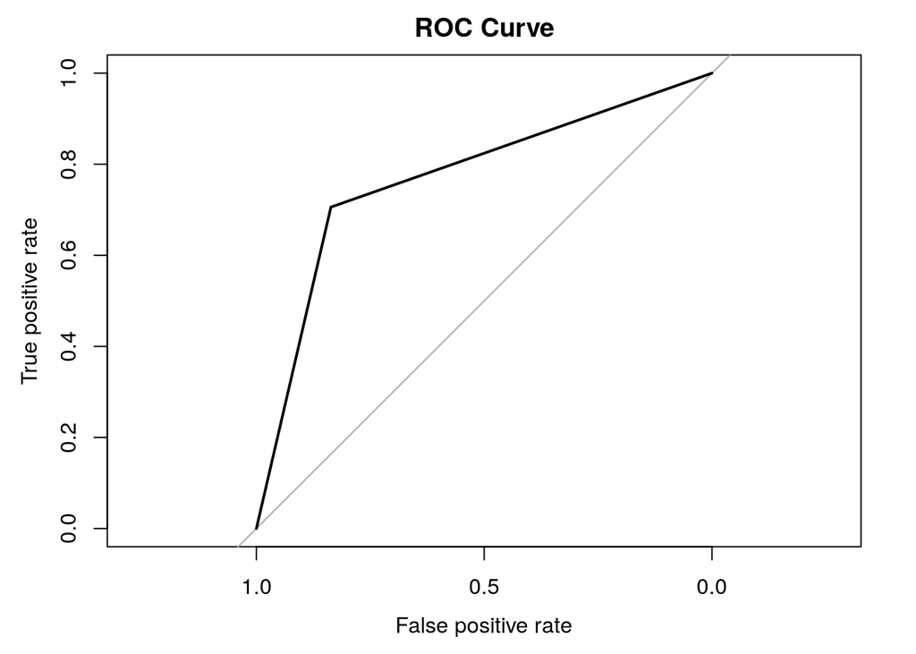

```r
PredictionsWithProbs <- predict(modelRandom, test_dataset, type = 'prob')
auc <- auc(test_dataset$label, PredictionsWithProbs[,2])
plot(roc(test_dataset$label, PredictionsWithProbs[,2]), main = 'ROC Curve',ylab ='True positive rate' ,xlab = 'False positive rate')
```

## Prediction

```r
PredictionsWithClass <- predict(modelRandom, test_dataset, type = 'class')
t <- table(predictions = PredictionsWithClass, actual = test_dataset$label)
t
```

```
##            actual
## predictions  0  1
##           0 92 20
##           1 18 48
```

```r
## Accuracy metric

sum(diag(t)/sum(t))
```

```
## [1] 0.7865169
```